# Risk Factor Analysis

## Outcome Variable

**Outcome Variable:** stunted

## Predictor Variables

**Intervention Variable:** meducyrs

**Adjustment Set:**

unadjusted

## Stratifying Variables

The analysis was stratified on these variable(s):

- agecat
- studyid
- country

## Data Summary

| agecat | studyid | country | meducyrs | stunted | n_cell | n |
| --- | --- | --- | --- | --- | --- | --- |
| Birth | CMC-V-BCS-2002 | INDIA | High | 0 | 43 | 92 |
| Birth | CMC-V-BCS-2002 | INDIA | High | 1 | 8 | 92 |
| Birth | CMC-V-BCS-2002 | INDIA | Low | 0 | 14 | 92 |
| Birth | CMC-V-BCS-2002 | INDIA | Low | 1 | 2 | 92 |
| Birth | CMC-V-BCS-2002 | INDIA | Medium | 0 | 18 | 92 |
| Birth | CMC-V-BCS-2002 | INDIA | Medium | 1 | 7 | 92 |
| Birth | COHORTS | GUATEMALA | High | 0 | 168 | 842 |
| Birth | COHORTS | GUATEMALA | High | 1 | 10 | 842 |
| Birth | COHORTS | GUATEMALA | Low | 0 | 361 | 842 |
| Birth | COHORTS | GUATEMALA | Low | 1 | 30 | 842 |
| Birth | COHORTS | GUATEMALA | Medium | 0 | 264 | 842 |
| Birth | COHORTS | GUATEMALA | Medium | 1 | 9 | 842 |
| Birth | COHORTS | INDIA | High | 0 | 626 | 5216 |
| Birth | COHORTS | INDIA | High | 1 | 52 | 5216 |
| Birth | COHORTS | INDIA | Low | 0 | 1505 | 5216 |
| Birth | COHORTS | INDIA | Low | 1 | 251 | 5216 |
| Birth | COHORTS | INDIA | Medium | 0 | 2468 | 5216 |
| Birth | COHORTS | INDIA | Medium | 1 | 314 | 5216 |
| Birth | COHORTS | PHILIPPINES | High | 0 | 1114 | 3050 |
| Birth | COHORTS | PHILIPPINES | High | 1 | 55 | 3050 |
| Birth | COHORTS | PHILIPPINES | Low | 0 | 830 | 3050 |
| Birth | COHORTS | PHILIPPINES | Low | 1 | 70 | 3050 |
| Birth | COHORTS | PHILIPPINES | Medium | 0 | 919 | 3050 |
| Birth | COHORTS | PHILIPPINES | Medium | 1 | 62 | 3050 |
| Birth | EE | PAKISTAN | High | 0 | 4 | 239 |
| Birth | EE | PAKISTAN | High | 1 | 3 | 239 |
| Birth | EE | PAKISTAN | Low | 0 | 122 | 239 |
| Birth | EE | PAKISTAN | Low | 1 | 93 | 239 |
| Birth | EE | PAKISTAN | Medium | 0 | 14 | 239 |
| Birth | EE | PAKISTAN | Medium | 1 | 3 | 239 |

[output cut: 360 more lines]

The following strata were considered:

- agecat: 24 months, studyid: CMC-V-BCS-2002, country: INDIA
- agecat: 24 months, studyid: COHORTS, country: GUATEMALA
- agecat: 24 months, studyid: COHORTS, country: INDIA
- agecat: 24 months, studyid: COHORTS, country: PHILIPPINES
- agecat: 24 months, studyid: EE, country: PAKISTAN
- agecat: 24 months, studyid: GMS-Nepal, country: NEPAL
- agecat: 24 months, studyid: IRC, country: INDIA
- agecat: 24 months, studyid: LCNI-5, country: MALAWI
- agecat: 24 months, studyid: MAL-ED, country: BANGLADESH
- agecat: 24 months, studyid: MAL-ED, country: BRAZIL
- agecat: 24 months, studyid: MAL-ED, country: INDIA
- agecat: 24 months, studyid: MAL-ED, country: NEPAL
- agecat: 24 months, studyid: MAL-ED, country: PERU
- agecat: 24 months, studyid: MAL-ED, country: SOUTH AFRICA
- agecat: 24 months, studyid: MAL-ED, country: TANZANIA, UNITED REPUBLIC OF
- agecat: 24 months, studyid: NIH-Birth, country: BANGLADESH
- agecat: 24 months, studyid: NIH-Crypto, country: BANGLADESH
- agecat: 24 months, studyid: PROBIT, country: BELARUS
- agecat: 24 months, studyid: PROVIDE, country: BANGLADESH
- agecat: 24 months, studyid: TanzaniaChild2, country: TANZANIA, UNITED REPUBLIC OF
- agecat: 24 months, studyid: ZVITAMBO, country: ZIMBABWE
- agecat: 6 months, studyid: CMC-V-BCS-2002, country: INDIA
- agecat: 6 months, studyid: COHORTS, country: GUATEMALA
- agecat: 6 months, studyid: COHORTS, country: INDIA
- agecat: 6 months, studyid: COHORTS, country: PHILIPPINES
- agecat: 6 months, studyid: EE, country: PAKISTAN
- agecat: 6 months, studyid: GMS-Nepal, country: NEPAL
- agecat: 6 months, studyid: Guatemala BSC, country: GUATEMALA
- agecat: 6 months, studyid: IRC, country: INDIA
- agecat: 6 months, studyid: LCNI-5, country: MALAWI
- agecat: 6 months, studyid: MAL-ED, country: BANGLADESH
- agecat: 6 months, studyid: MAL-ED, country: BRAZIL
- agecat: 6 months, studyid: MAL-ED, country: INDIA
- agecat: 6 months, studyid: MAL-ED, country: NEPAL
- agecat: 6 months, studyid: MAL-ED, country: PERU
- agecat: 6 months, studyid: MAL-ED, country: SOUTH AFRICA
- agecat: 6 months, studyid: MAL-ED, country: TANZANIA, UNITED REPUBLIC OF
- agecat: 6 months, studyid: NIH-Birth, country: BANGLADESH
- agecat: 6 months, studyid: NIH-Crypto, country: BANGLADESH
- agecat: 6 months, studyid: PROBIT, country: BELARUS
- agecat: 6 months, studyid: PROVIDE, country: BANGLADESH
- agecat: 6 months, studyid: SAS-CompFeed, country: INDIA
- agecat: 6 months, studyid: SAS-FoodSuppl, country: INDIA
- agecat: 6 months, studyid: TanzaniaChild2, country: TANZANIA, UNITED REPUBLIC OF
- agecat: 6 months, studyid: ZVITAMBO, country: ZIMBABWE
- agecat: Birth, studyid: CMC-V-BCS-2002, country: INDIA
- agecat: Birth, studyid: COHORTS, country: GUATEMALA
- agecat: Birth, studyid: COHORTS, country: INDIA
- agecat: Birth, studyid: COHORTS, country: PHILIPPINES
- agecat: Birth, studyid: EE, country: PAKISTAN
- agecat: Birth, studyid: GMS-Nepal, country: NEPAL
- agecat: Birth, studyid: IRC, country: INDIA
- agecat: Birth, studyid: MAL-ED, country: BANGLADESH
- agecat: Birth, studyid: MAL-ED, country: BRAZIL
- agecat: Birth, studyid: MAL-ED, country: INDIA
- agecat: Birth, studyid: MAL-ED, country: NEPAL
- agecat: Birth, studyid: MAL-ED, country: PERU
- agecat: Birth, studyid: MAL-ED, country: SOUTH AFRICA
- agecat: Birth, studyid: MAL-ED, country: TANZANIA, UNITED REPUBLIC OF
- agecat: Birth, studyid: NIH-Birth, country: BANGLADESH
- agecat: Birth, studyid: NIH-Crypto, country: BANGLADESH
- agecat: Birth, studyid: PROBIT, country: BELARUS
- agecat: Birth, studyid: PROVIDE, country: BANGLADESH
- agecat: Birth, studyid: SAS-CompFeed, country: INDIA
- agecat: Birth, studyid: ZVITAMBO, country: ZIMBABWE

### Dropped Strata

Some strata were dropped due to rare outcomes:

- agecat: Birth, studyid: CMC-V-BCS-2002, country: INDIA
- agecat: Birth, studyid: EE, country: PAKISTAN
- agecat: Birth, studyid: MAL-ED, country: BRAZIL
- agecat: Birth, studyid: MAL-ED, country: INDIA
- agecat: Birth, studyid: MAL-ED, country: NEPAL
- agecat: Birth, studyid: MAL-ED, country: SOUTH AFRICA
- agecat: Birth, studyid: MAL-ED, country: TANZANIA, UNITED REPUBLIC OF
- agecat: Birth, studyid: PROBIT, country: BELARUS
- agecat: 6 months, studyid: EE, country: PAKISTAN
- agecat: 6 months, studyid: MAL-ED, country: BRAZIL
- agecat: 6 months, studyid: MAL-ED, country: NEPAL
- agecat: 6 months, studyid: MAL-ED, country: TANZANIA, UNITED REPUBLIC OF
- agecat: 24 months, studyid: EE, country: PAKISTAN
- agecat: 24 months, studyid: MAL-ED, country: BRAZIL
- agecat: 24 months, studyid: MAL-ED, country: TANZANIA, UNITED REPUBLIC OF
- agecat: 24 months, studyid: TanzaniaChild2, country: TANZANIA, UNITED REPUBLIC OF

## Methods Detail

We’re interested in the causal parameters $E[Y_a]$ for all values of $a \in \mathcal{A}$. These parameters represent the mean outcome if, possibly contrary to fact, we intervened to set all units to have $A=a$. Under the randomization and positivity assumptions, these are identified by the statistical parameters $\psi_a=E_W[E_{Y|A,W}(Y|A=a,W)]$. In addition, we’re interested in the mean of $Y$, $E[Y]$ under no intervention (the observed mean). We will estimate these parameters by using SuperLearner to fit the relevant likelihood factors – $E_{Y|A,W}(Y|A=a,W)$ and $p(A=a|W)$, and then updating our likelihood fit using a joint TMLE.

For unadjusted analyses ($W=\{\}$), initial likelihoods were estimated using Lrnr_glm to estimate the simple $E(Y|A)$ and Lrnr_mean to estimate $p(A)$. For adjusted analyses, a small library containing Lrnr_glmnet, Lrnr_xgboost, and Lrnr_mean was used.

Having estimated these parameters, we will then use the delta method to estimate relative risks and attributable risks relative to a prespecified baseline level of $A$.

# Results Detail

## Results Plots

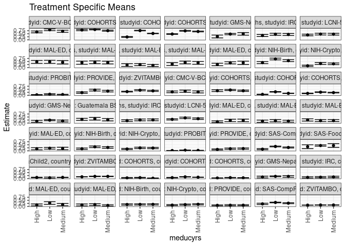

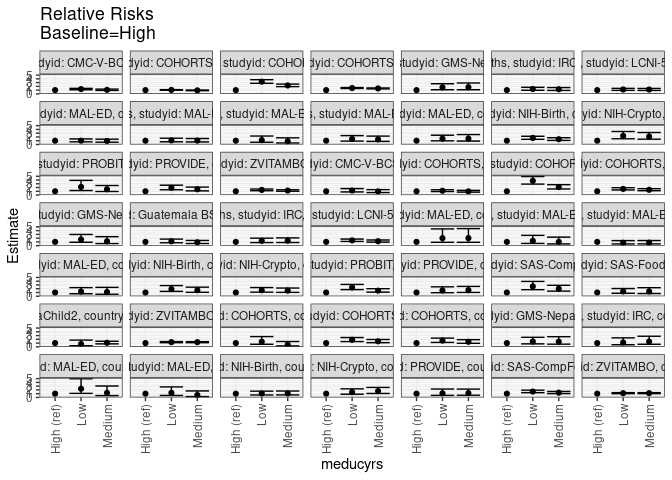

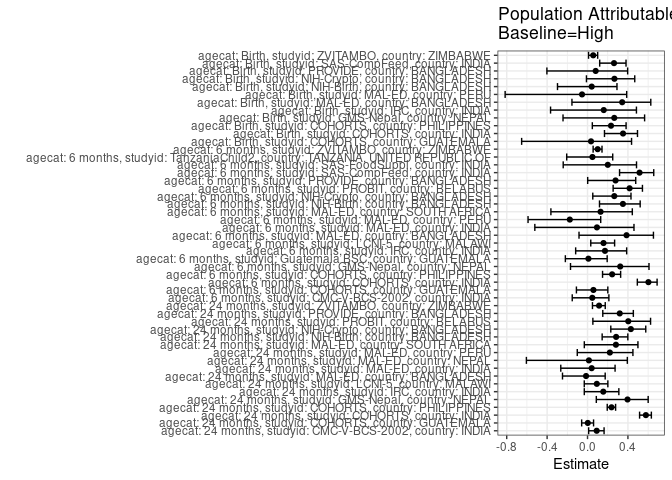

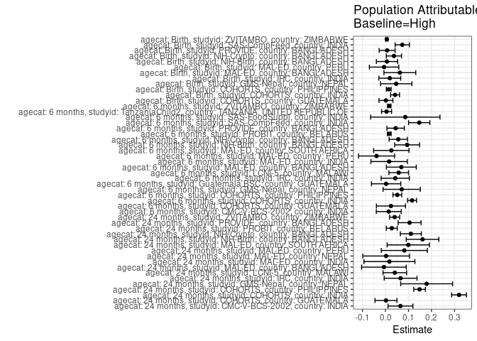

## Results Table

### Parameter: TSM

| agecat | studyid | country | intervention_level | baseline_level | estimate | ci_lower | ci_upper |
| --- | --- | --- | --- | --- | --- | --- | --- |
| Birth | COHORTS | GUATEMALA | High | NA | 0.0561798 | 0.0223319 | 0.0900276 |
| Birth | COHORTS | GUATEMALA | Low | NA | 0.0767263 | 0.0503293 | 0.1031234 |
| Birth | COHORTS | GUATEMALA | Medium | NA | 0.0329670 | 0.0117744 | 0.0541597 |
| Birth | COHORTS | INDIA | High | NA | 0.0766962 | 0.0566637 | 0.0967286 |
| Birth | COHORTS | INDIA | Low | NA | 0.1429385 | 0.1265663 | 0.1593107 |
| Birth | COHORTS | INDIA | Medium | NA | 0.1128684 | 0.1011089 | 0.1246280 |
| Birth | COHORTS | PHILIPPINES | High | NA | 0.0470488 | 0.0349087 | 0.0591888 |
| Birth | COHORTS | PHILIPPINES | Low | NA | 0.0777778 | 0.0602776 | 0.0952780 |
| Birth | COHORTS | PHILIPPINES | Medium | NA | 0.0632008 | 0.0479719 | 0.0784297 |
| Birth | GMS-Nepal | NEPAL | High | NA | 0.1294118 | 0.0580040 | 0.2008195 |
| Birth | GMS-Nepal | NEPAL | Low | NA | 0.1835052 | 0.1490312 | 0.2179792 |
| Birth | GMS-Nepal | NEPAL | Medium | NA | 0.1788618 | 0.1110858 | 0.2466378 |
| Birth | IRC | INDIA | High | NA | 0.0973451 | 0.0426199 | 0.1520703 |
| Birth | IRC | INDIA | Low | NA | 0.1126761 | 0.0606020 | 0.1647501 |
| Birth | IRC | INDIA | Medium | NA | 0.1353383 | 0.0771259 | 0.1935508 |
| Birth | MAL-ED | BANGLADESH | High | NA | 0.1194030 | 0.0415507 | 0.1972552 |
| Birth | MAL-ED | BANGLADESH | Low | NA | 0.2769231 | 0.1678475 | 0.3859987 |
| Birth | MAL-ED | BANGLADESH | Medium | NA | 0.1454545 | 0.0520297 | 0.2388794 |
| Birth | MAL-ED | PERU | High | NA | 0.1176471 | 0.0409040 | 0.1943902 |
| Birth | MAL-ED | PERU | Low | NA | 0.1428571 | 0.0678643 | 0.2178500 |
| Birth | MAL-ED | PERU | Medium | NA | 0.0740741 | 0.0169182 | 0.1312299 |
| Birth | NIH-Birth | BANGLADESH | High | NA | 0.1529412 | 0.0987910 | 0.2070914 |
| Birth | NIH-Birth | BANGLADESH | Low | NA | 0.1607143 | 0.1125790 | 0.2088496 |
| Birth | NIH-Birth | BANGLADESH | Medium | NA | 0.1635514 | 0.1139555 | 0.2131473 |
| Birth | NIH-Crypto | BANGLADESH | High | NA | 0.1012146 | 0.0635749 | 0.1388543 |
| Birth | NIH-Crypto | BANGLADESH | Low | NA | 0.1422414 | 0.0972638 | 0.1872190 |
| Birth | NIH-Crypto | BANGLADESH | Medium | NA | 0.1699605 | 0.1236469 | 0.2162740 |
| Birth | PROVIDE | BANGLADESH | High | NA | 0.0818713 | 0.0407402 | 0.1230025 |
| Birth | PROVIDE | BANGLADESH | Low | NA | 0.0909091 | 0.0470038 | 0.1348144 |
| Birth | PROVIDE | BANGLADESH | Medium | NA | 0.0935961 | 0.0534916 | 0.1337005 |

[output cut: 117 more lines]

### Parameter: E(Y)

| agecat | studyid | country | intervention_level | baseline_level | estimate | ci_lower | ci_upper |
| --- | --- | --- | --- | --- | --- | --- | --- |
| Birth | COHORTS | GUATEMALA | NA | NA | 0.0581948 | 0.0423724 | 0.0740172 |
| Birth | COHORTS | INDIA | NA | NA | 0.1182899 | 0.1095248 | 0.1270550 |
| Birth | COHORTS | PHILIPPINES | NA | NA | 0.0613115 | 0.0527962 | 0.0698268 |
| Birth | GMS-Nepal | NEPAL | NA | NA | 0.1760462 | 0.1476696 | 0.2044227 |
| Birth | IRC | INDIA | NA | NA | 0.1159794 | 0.0840777 | 0.1478811 |
| Birth | MAL-ED | BANGLADESH | NA | NA | 0.1818182 | 0.1263894 | 0.2372469 |
| Birth | MAL-ED | PERU | NA | NA | 0.1115880 | 0.0710726 | 0.1521034 |
| Birth | NIH-Birth | BANGLADESH | NA | NA | 0.1595395 | 0.1304091 | 0.1886699 |
| Birth | NIH-Crypto | BANGLADESH | NA | NA | 0.1379781 | 0.1129774 | 0.1629789 |
| Birth | PROVIDE | BANGLADESH | NA | NA | 0.0890538 | 0.0649864 | 0.1131212 |
| Birth | SAS-CompFeed | INDIA | NA | NA | 0.2787540 | 0.2475949 | 0.3099131 |
| Birth | ZVITAMBO | ZIMBABWE | NA | NA | 0.1035005 | 0.0984282 | 0.1085729 |
| 6 months | CMC-V-BCS-2002 | INDIA | NA | NA | 0.3008130 | 0.2539566 | 0.3476694 |
| 6 months | COHORTS | GUATEMALA | NA | NA | 0.4075630 | 0.3763327 | 0.4387933 |
| 6 months | COHORTS | INDIA | NA | NA | 0.1915758 | 0.1810911 | 0.2020606 |
| 6 months | COHORTS | PHILIPPINES | NA | NA | 0.2112260 | 0.1958496 | 0.2266024 |
| 6 months | GMS-Nepal | NEPAL | NA | NA | 0.2174688 | 0.1833021 | 0.2516355 |
| 6 months | Guatemala BSC | GUATEMALA | NA | NA | 0.3104693 | 0.2558835 | 0.3650551 |
| 6 months | IRC | INDIA | NA | NA | 0.2457002 | 0.2038248 | 0.2875757 |
| 6 months | LCNI-5 | MALAWI | NA | NA | 0.3628536 | 0.3297820 | 0.3959252 |
| 6 months | MAL-ED | BANGLADESH | NA | NA | 0.1785714 | 0.1248161 | 0.2323268 |
| 6 months | MAL-ED | INDIA | NA | NA | 0.1682692 | 0.1173060 | 0.2192324 |
| 6 months | MAL-ED | PERU | NA | NA | 0.2205882 | 0.1712211 | 0.2699554 |
| 6 months | MAL-ED | SOUTH AFRICA | NA | NA | 0.1968504 | 0.1478551 | 0.2458457 |
| 6 months | NIH-Birth | BANGLADESH | NA | NA | 0.2681564 | 0.2306532 | 0.3056597 |
| 6 months | NIH-Crypto | BANGLADESH | NA | NA | 0.2097902 | 0.1799252 | 0.2396552 |
| 6 months | PROBIT | BELARUS | NA | NA | 0.0393401 | 0.0293640 | 0.0493162 |
| 6 months | PROVIDE | BANGLADESH | NA | NA | 0.1589404 | 0.1297581 | 0.1881227 |
| 6 months | SAS-CompFeed | INDIA | NA | NA | 0.2844311 | 0.2666491 | 0.3022132 |
| 6 months | SAS-FoodSuppl | INDIA | NA | NA | 0.4289474 | 0.3791199 | 0.4787748 |
| 6 months | TanzaniaChild2 | TANZANIA, UNITED REPUBLIC OF | NA | NA | 0.0964869 | 0.0836111 | 0.1093627 |
| 6 months | ZVITAMBO | ZIMBABWE | NA | NA | 0.1631427 | 0.1553579 | 0.1709275 |
| 24 months | CMC-V-BCS-2002 | INDIA | NA | NA | 0.7169811 | 0.6710815 | 0.7628807 |
| 24 months | COHORTS | GUATEMALA | NA | NA | 0.8107852 | 0.7871616 | 0.8344089 |
| 24 months | COHORTS | INDIA | NA | NA | 0.5531205 | 0.5380793 | 0.5681618 |
| 24 months | COHORTS | PHILIPPINES | NA | NA | 0.6229039 | 0.6036892 | 0.6421186 |
| 24 months | GMS-Nepal | NEPAL | NA | NA | 0.4515464 | 0.4072114 | 0.4958814 |
| 24 months | IRC | INDIA | NA | NA | 0.4205379 | 0.3726382 | 0.4684376 |
| 24 months | LCNI-5 | MALAWI | NA | NA | 0.4405594 | 0.3998393 | 0.4812796 |
| 24 months | MAL-ED | BANGLADESH | NA | NA | 0.4619883 | 0.3870446 | 0.5369320 |
| 24 months | MAL-ED | INDIA | NA | NA | 0.4170854 | 0.3484054 | 0.4857655 |
| 24 months | MAL-ED | NEPAL | NA | NA | 0.2112676 | 0.1563184 | 0.2662168 |
| 24 months | MAL-ED | PERU | NA | NA | 0.3700000 | 0.3029201 | 0.4370799 |
| 24 months | MAL-ED | SOUTH AFRICA | NA | NA | 0.3529412 | 0.2921001 | 0.4137823 |
| 24 months | NIH-Birth | BANGLADESH | NA | NA | 0.5687646 | 0.5218455 | 0.6156837 |
| 24 months | NIH-Crypto | BANGLADESH | NA | NA | 0.2568093 | 0.2190047 | 0.2946140 |
| 24 months | PROBIT | BELARUS | NA | NA | 0.0681537 | 0.0420376 | 0.0942697 |
| 24 months | PROVIDE | BANGLADESH | NA | NA | 0.3287197 | 0.2903909 | 0.3670485 |
| 24 months | ZVITAMBO | ZIMBABWE | NA | NA | 0.3471629 | 0.3241082 | 0.3702176 |

### Parameter: RR

| agecat | studyid | country | intervention_level | baseline_level | estimate | ci_lower | ci_upper |
| --- | --- | --- | --- | --- | --- | --- | --- |
| Birth | COHORTS | GUATEMALA | High | High | 1.0000000 | 1.0000000 | 1.000000 |
| Birth | COHORTS | GUATEMALA | Low | High | 1.3657289 | 0.6824179 | 2.733245 |
| Birth | COHORTS | GUATEMALA | Medium | High | 0.5868132 | 0.2431453 | 1.416230 |
| Birth | COHORTS | INDIA | High | High | 1.0000000 | 1.0000000 | 1.000000 |
| Birth | COHORTS | INDIA | Low | High | 1.8636981 | 1.4012426 | 2.478779 |
| Birth | COHORTS | INDIA | Medium | High | 1.4716308 | 1.1108945 | 1.949508 |
| Birth | COHORTS | PHILIPPINES | High | High | 1.0000000 | 1.0000000 | 1.000000 |
| Birth | COHORTS | PHILIPPINES | Low | High | 1.6531313 | 1.1738824 | 2.328038 |
| Birth | COHORTS | PHILIPPINES | Medium | High | 1.3433046 | 0.9437302 | 1.912058 |
| Birth | GMS-Nepal | NEPAL | High | High | 1.0000000 | 1.0000000 | 1.000000 |
| Birth | GMS-Nepal | NEPAL | Low | High | 1.4179944 | 0.7916407 | 2.539925 |
| Birth | GMS-Nepal | NEPAL | Medium | High | 1.3821138 | 0.7076849 | 2.699279 |
| Birth | IRC | INDIA | High | High | 1.0000000 | 1.0000000 | 1.000000 |
| Birth | IRC | INDIA | Low | High | 1.1574904 | 0.5590569 | 2.396507 |
| Birth | IRC | INDIA | Medium | High | 1.3902939 | 0.6850014 | 2.821771 |
| Birth | MAL-ED | BANGLADESH | High | High | 1.0000000 | 1.0000000 | 1.000000 |
| Birth | MAL-ED | BANGLADESH | Low | High | 2.3192308 | 1.0827284 | 4.967849 |
| Birth | MAL-ED | BANGLADESH | Medium | High | 1.2181818 | 0.4877850 | 3.042256 |
| Birth | MAL-ED | PERU | High | High | 1.0000000 | 1.0000000 | 1.000000 |
| Birth | MAL-ED | PERU | Low | High | 1.2142857 | 0.5256316 | 2.805177 |
| Birth | MAL-ED | PERU | Medium | High | 0.6296296 | 0.2292335 | 1.729387 |
| Birth | NIH-Birth | BANGLADESH | High | High | 1.0000000 | 1.0000000 | 1.000000 |
| Birth | NIH-Birth | BANGLADESH | Low | High | 1.0508242 | 0.6608858 | 1.670835 |
| Birth | NIH-Birth | BANGLADESH | Medium | High | 1.0693746 | 0.6709264 | 1.704452 |
| Birth | NIH-Crypto | BANGLADESH | High | High | 1.0000000 | 1.0000000 | 1.000000 |
| Birth | NIH-Crypto | BANGLADESH | Low | High | 1.4053448 | 0.8625537 | 2.289706 |
| Birth | NIH-Crypto | BANGLADESH | Medium | High | 1.6792095 | 1.0589659 | 2.662734 |
| Birth | PROVIDE | BANGLADESH | High | High | 1.0000000 | 1.0000000 | 1.000000 |
| Birth | PROVIDE | BANGLADESH | Low | High | 1.1103896 | 0.5531261 | 2.229085 |
| Birth | PROVIDE | BANGLADESH | Medium | High | 1.1432090 | 0.5906934 | 2.212530 |

[output cut: 117 more lines]

### Parameter: PAR

| agecat | studyid | country | intervention_level | baseline_level | estimate | ci_lower | ci_upper |
| --- | --- | --- | --- | --- | --- | --- | --- |
| Birth | COHORTS | GUATEMALA | High | NA | 0.0020150 | -0.0281782 | 0.0322082 |
| Birth | COHORTS | INDIA | High | NA | 0.0415937 | 0.0222598 | 0.0609276 |
| Birth | COHORTS | PHILIPPINES | High | NA | 0.0142627 | 0.0039227 | 0.0246027 |
| Birth | GMS-Nepal | NEPAL | High | NA | 0.0466344 | -0.0215818 | 0.1148506 |
| Birth | IRC | INDIA | High | NA | 0.0186342 | -0.0289908 | 0.0662593 |
| Birth | MAL-ED | BANGLADESH | High | NA | 0.0624152 | -0.0067958 | 0.1316262 |
| Birth | MAL-ED | PERU | High | NA | -0.0060591 | -0.0700384 | 0.0579202 |
| Birth | NIH-Birth | BANGLADESH | High | NA | 0.0065983 | -0.0396735 | 0.0528701 |
| Birth | NIH-Crypto | BANGLADESH | High | NA | 0.0367636 | 0.0038140 | 0.0697132 |
| Birth | PROVIDE | BANGLADESH | High | NA | 0.0071825 | -0.0274235 | 0.0417884 |
| Birth | SAS-CompFeed | INDIA | High | NA | 0.0731088 | 0.0420986 | 0.1041191 |
| Birth | ZVITAMBO | ZIMBABWE | High | NA | 0.0058292 | 0.0011487 | 0.0105098 |
| 6 months | CMC-V-BCS-2002 | INDIA | High | NA | 0.0141888 | -0.0400629 | 0.0684405 |
| 6 months | COHORTS | GUATEMALA | High | NA | 0.0237792 | -0.0393129 | 0.0868714 |
| 6 months | COHORTS | INDIA | High | NA | 0.1154889 | 0.0960695 | 0.1349083 |
| 6 months | COHORTS | PHILIPPINES | High | NA | 0.0514627 | 0.0323791 | 0.0705462 |
| 6 months | GMS-Nepal | NEPAL | High | NA | 0.0704100 | -0.0104917 | 0.1513117 |
| 6 months | Guatemala BSC | GUATEMALA | High | NA | 0.0027770 | -0.0610137 | 0.0665677 |
| 6 months | IRC | INDIA | High | NA | 0.0424482 | -0.0188638 | 0.1037603 |
| 6 months | LCNI-5 | MALAWI | High | NA | 0.0574845 | 0.0147707 | 0.1001983 |
| 6 months | MAL-ED | BANGLADESH | High | NA | 0.0689824 | 0.0041266 | 0.1338382 |
| 6 months | MAL-ED | INDIA | High | NA | 0.0157269 | -0.0633729 | 0.0948266 |
| 6 months | MAL-ED | PERU | High | NA | -0.0386710 | -0.1169908 | 0.0396488 |
| 6 months | MAL-ED | SOUTH AFRICA | High | NA | 0.0254218 | -0.0514734 | 0.1023170 |
| 6 months | NIH-Birth | BANGLADESH | High | NA | 0.0939629 | 0.0399596 | 0.1479661 |
| 6 months | NIH-Crypto | BANGLADESH | High | NA | 0.0556235 | 0.0158885 | 0.0953586 |
| 6 months | PROBIT | BELARUS | High | NA | 0.0163819 | 0.0082764 | 0.0244873 |
| 6 months | PROVIDE | BANGLADESH | High | NA | 0.0441079 | 0.0063204 | 0.0818953 |
| 6 months | SAS-CompFeed | INDIA | High | NA | 0.1465001 | 0.1002750 | 0.1927252 |
| 6 months | SAS-FoodSuppl | INDIA | High | NA | 0.0860902 | -0.0646062 | 0.2367866 |
| 6 months | TanzaniaChild2 | TANZANIA, UNITED REPUBLIC OF | High | NA | 0.0046900 | -0.0170934 | 0.0264734 |
| 6 months | ZVITAMBO | ZIMBABWE | High | NA | 0.0163966 | 0.0092029 | 0.0235904 |
| 24 months | CMC-V-BCS-2002 | INDIA | High | NA | 0.0650824 | 0.0109815 | 0.1191833 |
| 24 months | COHORTS | GUATEMALA | High | NA | 0.0021728 | -0.0455694 | 0.0499150 |
| 24 months | COHORTS | INDIA | High | NA | 0.3195679 | 0.2874771 | 0.3516587 |
| 24 months | COHORTS | PHILIPPINES | High | NA | 0.1480680 | 0.1228927 | 0.1732433 |
| 24 months | GMS-Nepal | NEPAL | High | NA | 0.1788191 | 0.0661284 | 0.2915098 |
| 24 months | IRC | INDIA | High | NA | 0.0656992 | -0.0056659 | 0.1370643 |
| 24 months | LCNI-5 | MALAWI | High | NA | 0.0405594 | -0.0106939 | 0.0918128 |
| 24 months | MAL-ED | BANGLADESH | High | NA | -0.0067617 | -0.1037013 | 0.0901779 |
| 24 months | MAL-ED | INDIA | High | NA | 0.0170854 | -0.0936020 | 0.1277729 |
| 24 months | MAL-ED | NEPAL | High | NA | 0.0029343 | -0.0985745 | 0.1044430 |
| 24 months | MAL-ED | PERU | High | NA | 0.0818644 | -0.0181492 | 0.1818780 |
| 24 months | MAL-ED | SOUTH AFRICA | High | NA | 0.0992098 | 0.0072007 | 0.1912190 |
| 24 months | NIH-Birth | BANGLADESH | High | NA | 0.1610723 | 0.0902275 | 0.2319170 |
| 24 months | NIH-Crypto | BANGLADESH | High | NA | 0.1102125 | 0.0646424 | 0.1557825 |
| 24 months | PROBIT | BELARUS | High | NA | 0.0274910 | 0.0038774 | 0.0511046 |
| 24 months | PROVIDE | BANGLADESH | High | NA | 0.1048391 | 0.0550191 | 0.1546591 |
| 24 months | ZVITAMBO | ZIMBABWE | High | NA | 0.0397383 | 0.0177774 | 0.0616993 |

### Parameter: PAF

| agecat | studyid | country | intervention_level | baseline_level | estimate | ci_lower | ci_upper |
| --- | --- | --- | --- | --- | --- | --- | --- |
| Birth | COHORTS | GUATEMALA | High | NA | 0.0346251 | -0.6522240 | 0.4359429 |
| Birth | COHORTS | INDIA | High | NA | 0.3516253 | 0.1679490 | 0.4947548 |
| Birth | COHORTS | PHILIPPINES | High | NA | 0.2326272 | 0.0475041 | 0.3817705 |
| Birth | GMS-Nepal | NEPAL | High | NA | 0.2648987 | -0.2425656 | 0.5651144 |
| Birth | IRC | INDIA | High | NA | 0.1606686 | -0.3659840 | 0.4842713 |
| Birth | MAL-ED | BANGLADESH | High | NA | 0.3432836 | -0.1542075 | 0.6263441 |
| Birth | MAL-ED | PERU | High | NA | -0.0542986 | -0.8156860 | 0.3878095 |
| Birth | NIH-Birth | BANGLADESH | High | NA | 0.0413584 | -0.2972458 | 0.2915809 |
| Birth | NIH-Crypto | BANGLADESH | High | NA | 0.2664449 | -0.0106145 | 0.4675486 |
| Birth | PROVIDE | BANGLADESH | High | NA | 0.0806530 | -0.4022094 | 0.3972378 |
| Birth | SAS-CompFeed | INDIA | High | NA | 0.2622701 | 0.1204733 | 0.3812065 |
| Birth | ZVITAMBO | ZIMBABWE | High | NA | 0.0563206 | 0.0100662 | 0.1004138 |
| 6 months | CMC-V-BCS-2002 | INDIA | High | NA | 0.0471682 | -0.1513476 | 0.2114558 |
| 6 months | COHORTS | GUATEMALA | High | NA | 0.0583449 | -0.1099324 | 0.2011097 |
| 6 months | COHORTS | INDIA | High | NA | 0.6028364 | 0.4930796 | 0.6888290 |
| 6 months | COHORTS | PHILIPPINES | High | NA | 0.2436380 | 0.1488471 | 0.3278723 |
| 6 months | GMS-Nepal | NEPAL | High | NA | 0.3237705 | -0.1684635 | 0.6086430 |
| 6 months | Guatemala BSC | GUATEMALA | High | NA | 0.0089445 | -0.2193701 | 0.1945096 |
| 6 months | IRC | INDIA | High | NA | 0.1727642 | -0.1174172 | 0.3875886 |
| 6 months | LCNI-5 | MALAWI | High | NA | 0.1584234 | 0.0321187 | 0.2682458 |
| 6 months | MAL-ED | BANGLADESH | High | NA | 0.3863014 | -0.0842433 | 0.6526370 |
| 6 months | MAL-ED | INDIA | High | NA | 0.0934625 | -0.5216944 | 0.4599374 |
| 6 months | MAL-ED | PERU | High | NA | -0.1753086 | -0.5888389 | 0.1305913 |
| 6 months | MAL-ED | SOUTH AFRICA | High | NA | 0.1291429 | -0.3626165 | 0.4434295 |
| 6 months | NIH-Birth | BANGLADESH | High | NA | 0.3504032 | 0.1185897 | 0.5212491 |
| 6 months | NIH-Crypto | BANGLADESH | High | NA | 0.2651389 | 0.0520681 | 0.4303168 |
| 6 months | PROBIT | BELARUS | High | NA | 0.4164168 | 0.2535266 | 0.5437622 |
| 6 months | PROVIDE | BANGLADESH | High | NA | 0.2775120 | 0.0015277 | 0.4772124 |
| 6 months | SAS-CompFeed | INDIA | High | NA | 0.5150635 | 0.3171954 | 0.6555919 |
| 6 months | SAS-FoodSuppl | INDIA | High | NA | 0.2007011 | -0.2407365 | 0.4850811 |
| 6 months | TanzaniaChild2 | TANZANIA, UNITED REPUBLIC OF | High | NA | 0.0486078 | -0.2061016 | 0.2495266 |
| 6 months | ZVITAMBO | ZIMBABWE | High | NA | 0.1005048 | 0.0554895 | 0.1433747 |
| 24 months | CMC-V-BCS-2002 | INDIA | High | NA | 0.0907728 | 0.0112242 | 0.1639217 |
| 24 months | COHORTS | GUATEMALA | High | NA | 0.0026799 | -0.0579774 | 0.0598595 |
| 24 months | COHORTS | INDIA | High | NA | 0.5777545 | 0.5154516 | 0.6320466 |
| 24 months | COHORTS | PHILIPPINES | High | NA | 0.2377060 | 0.1951468 | 0.2780148 |
| 24 months | GMS-Nepal | NEPAL | High | NA | 0.3960149 | 0.0870134 | 0.6004345 |
| 24 months | IRC | INDIA | High | NA | 0.1562266 | -0.0319981 | 0.3101212 |
| 24 months | LCNI-5 | MALAWI | High | NA | 0.0920635 | -0.0322076 | 0.2013731 |
| 24 months | MAL-ED | BANGLADESH | High | NA | -0.0146361 | -0.2477530 | 0.1749277 |
| 24 months | MAL-ED | INDIA | High | NA | 0.0409639 | -0.2648144 | 0.2728179 |
| 24 months | MAL-ED | NEPAL | High | NA | 0.0138889 | -0.6052013 | 0.3942098 |
| 24 months | MAL-ED | PERU | High | NA | 0.2212552 | -0.1015387 | 0.4494578 |
| 24 months | MAL-ED | SOUTH AFRICA | High | NA | 0.2810945 | -0.0317381 | 0.4990734 |
| 24 months | NIH-Birth | BANGLADESH | High | NA | 0.2831967 | 0.1448531 | 0.3991594 |
| 24 months | NIH-Crypto | BANGLADESH | High | NA | 0.4291607 | 0.2304597 | 0.5765556 |
| 24 months | PROBIT | BELARUS | High | NA | 0.4033680 | 0.0529137 | 0.6241423 |
| 24 months | PROVIDE | BANGLADESH | High | NA | 0.3189317 | 0.1510926 | 0.4535870 |
| 24 months | ZVITAMBO | ZIMBABWE | High | NA | 0.1144659 | 0.0489219 | 0.1754929 |